# CompAREdesign: Time-to-event endpoint

Jordi Cortés Martínez, Marta Bofill Roig and Guadalupe Gómez Melis

2024-12-17

## Time-to-event endpoint: ZODIAC Trial

This example is based on the data from the ZODIAC trial [1].

ZODIAC was a multinational, randomised, double-blind, phase 3 study of vandetanib plus docetaxel (Sanofi - Aventis, Paris, France) versus placebo plus docetaxel in patients with locally advanced or metastatic NCSLC after progression following platinum-based first-line chemotherapy. The recent approval and increasing use of pemetrexed as first-line therapy in NSCLC suggest a continuing role for docetaxel as second-line therapy.

### Input Parameters

First of all, the information for the components of the composite endpoint should be defined.

```r
## Probabilities of observing the event in control arm during follow-up
p0_e1 <- 0.59   # Death
p0_e2 <- 0.74   # Disease Progression

## Effect size (Cause specific hazard ratios) for each endpoint
HR_e1 <- 0.91   # Death
HR_e2 <- 0.77   # Disease Progression

## Hazard rates over time
beta_e1 <- 2    # Death --> Increasing risk over time
beta_e2 <- 1    # Disease Progression --> Constant risk over time

## Correlation
rho      <- 0.1        # Correlation between components
rho_type <- 'Spearman' # Type of correlation measure
copula   <- 'Frank'    # Copula used to get the joint distribution

## Additional parameter
case  <- 3  # 1: No deaths;                  2: Death is the secondary event;
            # 3: Death is the primary event; 4: Both events are death by different causes
```

- **Endpoint 1:** Death
- **Endpoint 2:** Disease progression

Parameter

Description

p0_e1

Probability of observing event 1 in control arm during follow-up

p0_e2

Probability of observing event 2 in control arm during follow-up

HR_e1

Effect size (Cause specific hazard ratios) for endpoint 1

HR_e2

Effect size (Cause specific hazard ratios) for endpoint 2

beta_e1

Hazard rate over time for endpoint 1 (>1: Increasing risk over time)

beta_e2

Hazard rate over time for endpoint 2 (=1: Constant risk over time)

rho

Correlation between components

rho_type

Type of the correlation measure

copula

Copula used to get the joint distribution

case

Additional parameter:

1. No deaths
2. Death is the secondary event
3. Death is the primary event;
4. Both events are death by different

### ARE: Asymptotic Relatively Efficiency

Considering probabilities in control group of 0.59 and 0.74, and a treatment effect given by a Hazard Ratio of 0.91 and 0.77 for Endpoints 1 and 2, respectively, with a correlation of 0.1 between endpoint times, the Asymptotic Relative Efficiency (ARE) is 8.79.

Since the ARE is higher than 1, the use of the composite endpoint (CE) consisting of the union of both endpoints is recommended as the primary endpoint of the trial. That is, for a significance level of 0.025 and power of 0.9 the number of required patients you would need to attain the same power is 8.79 times if you use Endpoint 1 instead of CE.

As the ARE is greater than 1, the design using the composite endpoint as the primary endpoint is more efficient from the statistical point of view.

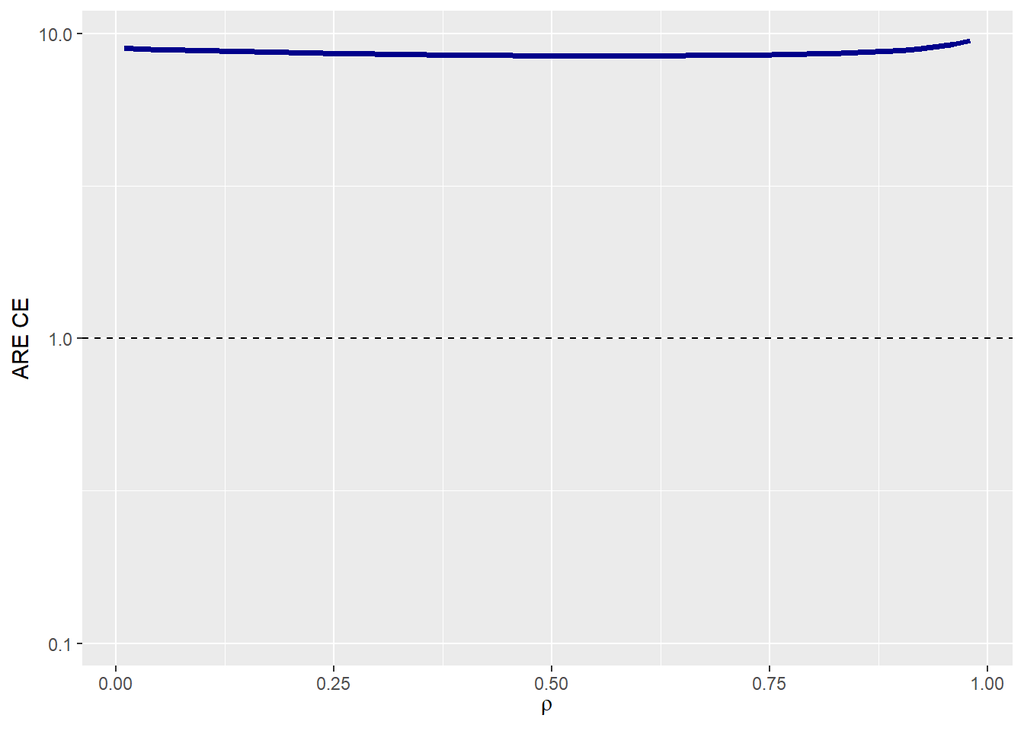

```
## [1] 8.791
```

```r
ARE_tte(p0_e1   = p0_e1    , p0_e2    = p0_e2,
        HR_e1   = HR_e1    , HR_e2    = HR_e2,
        beta_e1 = beta_e1  , beta_e2  = beta_e2,
        rho     = rho      , rho_type = rho_type,
        copula  = copula   , case     = case,
        plot_res = TRUE)
```

ARE CE remains constant and above 1 as a function of rho.

### Effect size of the Composite Endpoint

Several summary measures of the treatment effect are provided.

```
##  Effect measure Effect value | Group measure Reference Treated
##  -------------- ------------ | ------------- --------- -------
##  gAHR           0.8015       |
##  AHR            0.8016       |
##  RMST ratio     1.1633       | RMST          0.3918    0.4558
##  Median ratio   1.2321       | Median        0.3212    0.3958
##                              | Prob. E1      0.5900    0.5557
##                              | Prob. E2      0.7400    0.7125
##                              | Prob. CE      0.9300    0.8847
```

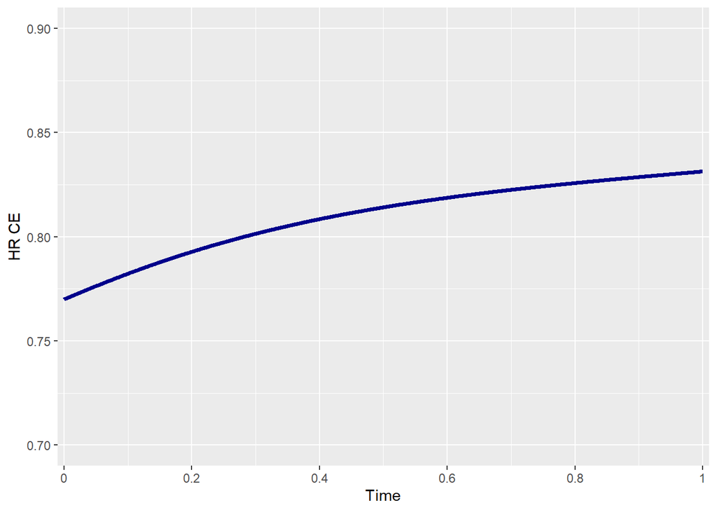

```r
effectsize_tte(p0_e1   = p0_e1    , p0_e2    = p0_e2,
               HR_e1   = HR_e1    , HR_e2    = HR_e2,
               beta_e1 = beta_e1  , beta_e2  = beta_e2,
               rho     = rho      , rho_type = rho_type,
               copula  = copula   , case     = case,
               plot_res = TRUE)
```

A slightly increase of HR CE can be seen as the time increases.

### Sample size

The required number of patients for the design of the trial using the composite endpoint as the primary endpoint is **1118**.

```
##  Endpoint           Total sample size
##  --------           -----------------
##  Endpoint 1         9744
##  Endpoint 2         1002
##  Composite endpoint 1118
```

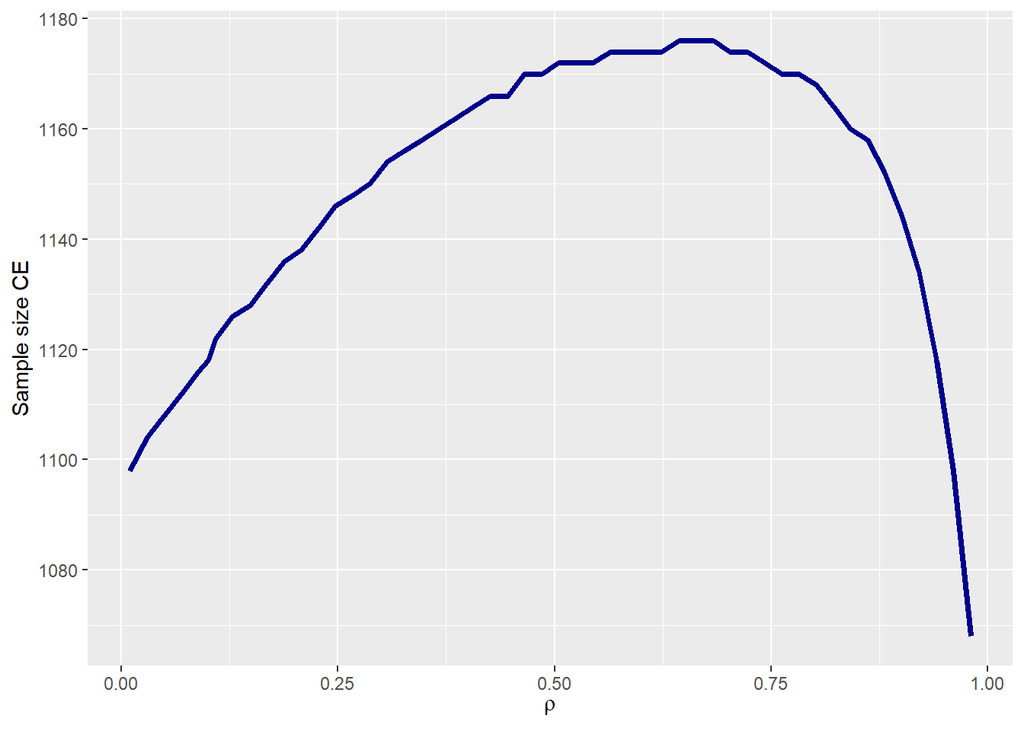

```r
samplesize_tte(p0_e1   = p0_e1    , p0_e2    = p0_e2,
               HR_e1   = HR_e1    , HR_e2    = HR_e2,
               beta_e1 = beta_e1  , beta_e2  = beta_e2,
               rho     = rho      , rho_type = rho_type,
               copula  = copula   , case     = case,
               alpha   = 0.025    , power    = 0.90,
               ss_formula = 'schoenfeld',
               plot_res = TRUE)
```

A different Sample size CE can be seen according to the correlation values. For a correlation of **0.1**, the sample size is **1118**.

### Influence of hazards rates over time on the effect size

The influence of the behaviour of the hazard rates over time on the treatment effect can be studied by the function `effectsize_tte`.

```
##  Effect measure Effect value | Group measure Reference Treated
##  -------------- ------------ | ------------- --------- -------
##  gAHR           0.8046       |
##  AHR            0.8046       |
##  RMST ratio     1.1310       | RMST          0.3070    0.3472
##  Median ratio   1.1310       | Median        0.2820    0.3190
##                              | Prob. E1      0.5900    0.5557
##                              | Prob. E2      0.7400    0.7381
##                              | Prob. CE      0.9986    0.9943
```

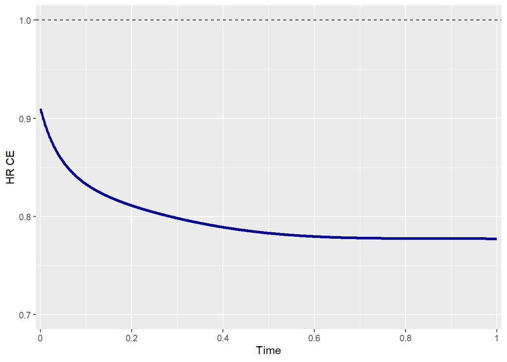

```r
## Hazard rates over time Scenario 1
beta_e1 <- 1    # Death --> constant over time
beta_e2 <- 2    # Disease Progression --> increase over time
effectsize_tte(p0_e1   = p0_e1    , p0_e2    = p0_e2,
               HR_e1   = HR_e1    , HR_e2    = HR_e2,
               beta_e1 = beta_e1  , beta_e2  = beta_e2,
               rho     = rho      , rho_type = rho_type,
               copula  = copula   , case     = case,
               plot_res = TRUE)
```

```
##  Effect measure Effect value | Group measure Reference Treated
##  -------------- ------------ | ------------- --------- -------
##  gAHR           0.8039       |
##  AHR            0.8039       |
##  RMST ratio     1.2055       | RMST          0.2804    0.3380
##  Median ratio   1.2454       | Median        0.1990    0.2478
##                              | Prob. E1      0.5900    0.5557
##                              | Prob. E2      0.7400    0.7332
##                              | Prob. CE      0.9676    0.9360
```

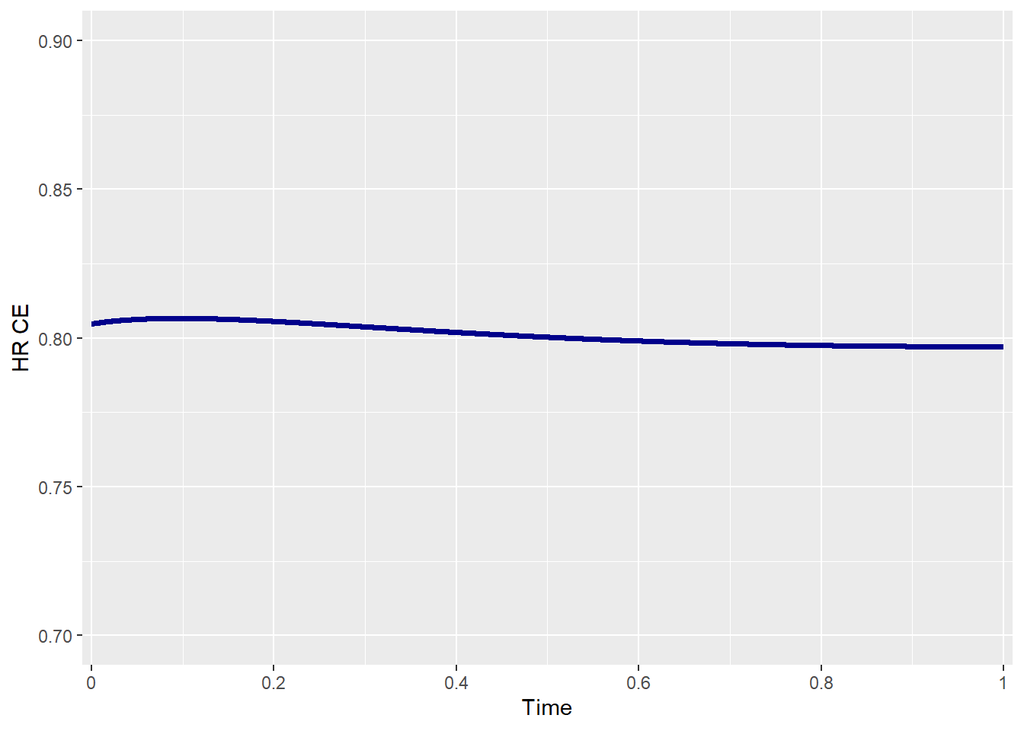

```r
## Hazard rates over time Scenario 2
beta_e1 <- 1    # Death --> constant over time
beta_e2 <- 1    # Disease Progression --> constant over time
effectsize_tte(p0_e1   = p0_e1    , p0_e2    = p0_e2,
               HR_e1   = HR_e1    , HR_e2    = HR_e2,
               beta_e1 = beta_e1  , beta_e2  = beta_e2,
               rho     = rho      , rho_type = rho_type,
               copula  = copula   , case     = case,
               plot_res = TRUE)
```

When the hazard rate of Event1 (Death) is constant over time and the hazard rate of Event 2 (Disease progresion) increases over time, the HR CE slightly decrease over time until it remains constant. When hazard rates of both events are constant over time, the HR CE tends to be more constant.

## References

1. Herbst RS, Sun Y, Eberhardt WEE, Germonpré P, Saijo N, Zhou C et al. Vandetanib plus docetaxel versus docetaxel as second-line treatment for patients with advanced non-small-cell lung cancer (ZODIAC): a double-blind, randomised, phase 3 trial. Lancet Oncol. 2010;11(7):619–26.
2. Kaul U, Bangalore S, Seth A, Priyadarshini A, Rajpal KA, Tejas MP et al. Paclitaxel-Eluting versus EverolimusEluting Coronary Stents in Diabetes. N Engl J Med. 2015;373(18):1709-19.